# Customised analysis

Arpan Kumar Basak

2023-07-09

## Hypergeometric test for Enrichment analysis

```r
deTable <-  matrix(c(28, 142, 501, 12000),
            nrow = 2,
            dimnames = list(DE=c("yes","no"),
                            PathwayGenes=c("in","out")))

deTable
```

```
##      PathwayGenes
## DE     in   out
##   yes  28   501
##   no  142 12000
```

Now form the contingency table we estimate whether genes in our gene set is statistically supported.

```r
fisher.test(deTable, alternative = "greater") # Enrichment
```

```
##
##  Fisher's Exact Test for Count Data
##
## data:  deTable
## p-value = 4.088e-10
## alternative hypothesis: true odds ratio is greater than 1
## 95 percent confidence interval:
##  3.226736      Inf
## sample estimates:
## odds ratio
##   4.721744
```

The gene ratio here is the odds ratio and the statistical significance is provided. One can iterate this over different pathways and estimate the statistical support for each by performing multiple hypothesis correction.

Alternatively one can perform gene enrichment score by cumulative sum of log<sub>2</sub>FC multiplied by cumulative sum of -log<sub>10</sub>p value. If you have DEGs then this type of analysis should give you a basis to select the top 10 pathways enriched upon experimental perturbation.

$$| log2FoldChange * -log10(p.adjust)
|$$

## Read the expression profile of the genes

```r
require(tidyverse)
df <- read.delim2("./data/Hou.et.al.txt", header = TRUE, row.names = 1, sep = "\t")
load("./gene_set_for_wounding.RData")

case_in <- "SC_Root"

id_deg <- str_detect(colnames(df), case_in)
lfc_mat <- df[,id_deg]
colnames(lfc_mat) <- str_replace_all(colnames(lfc_mat), paste0("\\.", case_in), "")
degs <- lfc_mat %>% dplyr::filter(abs(as.numeric(`log2FC`)) >= 1 & as.numeric(`FDR`) <= 0.05)
```

```r
# Lets estimate our parameters for hypergeometric test
N <- nrow(lfc_mat)
n <- nrow(degs)

m <- length(gs1)
k <- nrow(degs[row.names(degs) %in% gs1,])

deTable <-  matrix(c(k, m-k, n-k, N+k-n-m),
            nrow = 2,
            dimnames = list(DE=c("yes","no"),
                            PathwayGenes=c("in","out")))

deTable
```

```
##      PathwayGenes
## DE     in   out
##   yes  62  1490
##   no  183 19543
```

```r
(fstat <- fisher.test(deTable, alternative = "greater")) # Enrichment
```

```
##
##  Fisher's Exact Test for Count Data
##
## data:  deTable
## p-value < 2.2e-16
## alternative hypothesis: true odds ratio is greater than 1
## 95 percent confidence interval:
##  3.424427      Inf
## sample estimates:
## odds ratio
##   4.443212
```

### Enrinchment score calculation

Here we calculate the enrichment score for the genes that are present within the gene set of `Response to wounding`.

```r
across <- lfc_mat[gs1, ] %>%
  summarise(enrichment_score = abs(sum(as.numeric(log2FC))) * sum(-log10(as.numeric(FDR))))

within <- lfc_mat[gs1, ] %>%
  dplyr::filter(abs(as.numeric(`log2FC`)) >= 1 & as.numeric(`FDR`) <= 0.05) %>%
  summarise(enrichment_score = abs(sum(as.numeric(log2FC))) * sum(-log10(as.numeric(FDR))))

within/across * 100
```

```
##   enrichment_score
## 1         17.40835
```

### Summarising the customised analysis

Now lets plot the summarized statistics from the hypergeometric analysis, we are interested to see the distribution of gene expression and those that are in the gene list.

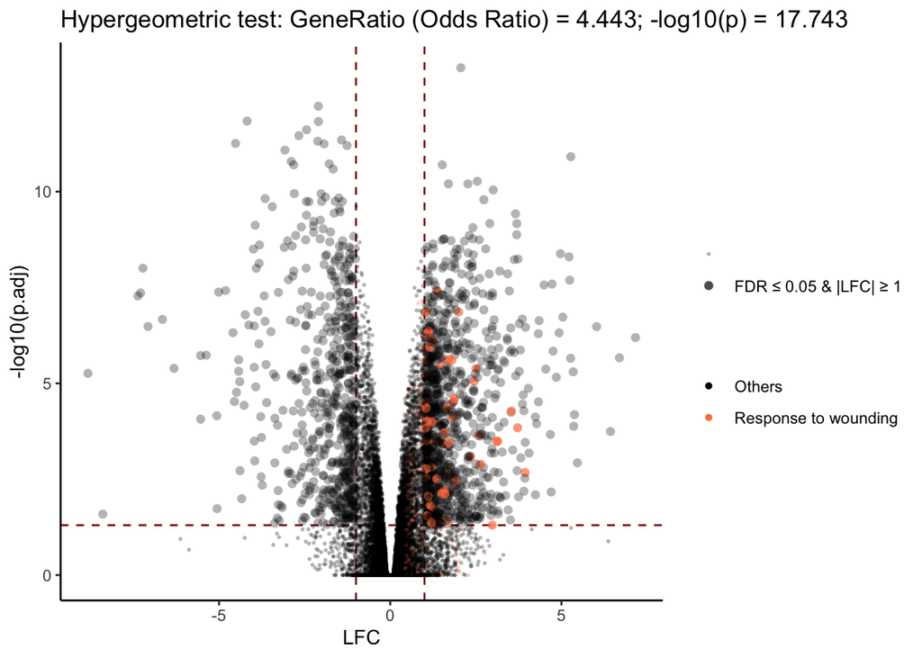

```r
lfc_mat %>%
  mutate(sig = abs(as.numeric(`log2FC`)) >= 1 & as.numeric(`FDR`) <= 0.05,
         gene_in = row.names(.) %in% gs1,
         log2FC = as.numeric(log2FC), FDR = -log10(as.numeric(FDR))) %>%
ggplot(aes(x = log2FC, y = FDR)) +
  ggtitle(paste0("Hypergeometric test: GeneRatio (Odds Ratio) = ", round(fstat$estimate, 3),"; -log10(p) = ", round(-log10(fstat$p.value), 3))) +
  geom_hline(yintercept = -log10(0.05), colour = "darkred", lty = "dashed") +
  geom_vline(xintercept = c(-1, 1), colour = "darkred", lty = "dashed") +
  geom_point(aes(size = (sig), colour = gene_in, alpha = (sig & gene_in)), shape = 16) +
  scale_alpha_manual(values = c(`TRUE` = 0.7, `FALSE` = 0.3), labels = c(`TRUE` = "FDR ≤ 0.05 & |LFC| ≥ 1", `FALSE` = "")) +
  scale_size_manual(values = c(`TRUE` = 2, `FALSE` = 0.7), labels = c(`TRUE` = "FDR ≤ 0.05 & |LFC| ≥ 1", `FALSE` = "")) +
  scale_colour_manual(values = c(`TRUE` = "coral", `FALSE` = "black"), labels = c(`TRUE` = "Response to wounding", `FALSE` = "Others")) +
  theme_classic() +
  labs(x= "LFC", y = "-log10(p.adj)", colour = "", size = "", alpha = "")
```